# Bellabeat Case Study: Smart Device Usage Analysis (English)

Maicon A Beyer

2025-10-23

## 1. Introduction and Business Focus (Phase: Ask)

### 1.1. Business Task

Analyze smart device usage data (Fitbit) to uncover consumer behavior insights and provide high-level recommendations for Bellabeat’s marketing strategy. The target is to identify patterns in activity and sleep and translate findings into actionable marketing/engagement recommendations.

### 1.2. Analysis Questions

1. What are the trends in smart device usage (activity, sedentary behavior, sleep)?
2. How can these trends be applied to Bellabeat customers?
3. Which recommendations and actions (Share/Act) should Bellabeat consider?

## 2. Data Preparation (Phase: Prepare)

### 2.1. Data Credibility (ROCCC Analysis)

Data were sourced from a public Kaggle dataset (“FitBit Fitness Tracker Data”).

**Conclusion:** We’ll proceed, highlighting sample and recency limitations in recommendations.

## 3. Data Processing (Phase: Process)

```r
# Load and clean the input CSVs: daily activity, weight, and sleep
# Daily activity files
ids_para_excluir <- c("6391747486", "2891001357") #ids with few data entries
daily_activity <- c(
  "data/Fitabase Data 3.12.16-4.11.16/dailyActivity_merged.csv",
  "data/Fitabase Data 4.12.16-5.12.16/dailyActivity_merged.csv"
) %>%
  map_dfr(~ read_csv(.x, col_select = c(Id, ActivityDate, TotalSteps, TotalDistance, VeryActiveMinutes, FairlyActiveMinutes, SedentaryMinutes, Calories))) %>%
  clean_names() %>%
  distinct() %>%
  rename(date = activity_date) %>%
  mutate(date = mdy(date)) %>%
  filter(
    !id %in% ids_para_excluir, #
    (total_distance * 1000 / total_steps) < 1, #steps should correspond to less than 1m per step
    total_steps > 0,
    total_distance > 0,
    sedentary_minutes < 1440,
    calories > 1000 #lowest calorie level a human consumes is 1200 calories, let's consider a 20% margin of error
  )

# Weight log files (weight and BMI)
weight_log <- c(
  "data/Fitabase Data 4.12.16-5.12.16/weightLogInfo_merged.csv",
  "data/Fitabase Data 3.12.16-4.11.16/weightLogInfo_merged.csv"
) %>%
  map_dfr(~ read_csv(.x, col_select = c(Id, Date, WeightKg, BMI))) %>%
  clean_names() %>%
  distinct() %>%
  mutate(date = as_date(mdy_hms(date)))%>%
  filter(!id %in% ids_para_excluir)

# Sleep minute data combined and summarized by day
sleep_day <- c(
  "data/Fitabase Data 3.12.16-4.11.16/minuteSleep_merged.csv",
  "data/Fitabase Data 4.12.16-5.12.16/minuteSleep_merged.csv"
) %>%
  map_dfr(~ read_csv(.x)) %>%
  clean_names() %>%
  distinct() %>%
  mutate(date = as_date(mdy_hms(date))) %>%
  filter(!id %in% ids_para_excluir)%>%
  group_by(id, date) %>%
  summarise(
    total_minutes_asleep = sum(value == 1, na.rm = TRUE),
    total_time_in_bed = n(),
    .groups = "drop"
  )
# Hourly Steps files
hourly_steps <- c(
  "data/Fitabase Data 3.12.16-4.11.16/hourlySteps_merged.csv",
  "data/Fitabase Data 4.12.16-5.12.16/hourlySteps_merged.csv"
) %>%
  map_dfr(read_csv) %>%
  clean_names() %>%
  distinct() %>%
  mutate(
    activity_hour = mdy_hms(activity_hour),
    date = as_date(activity_hour),
    hour_24 = format(activity_hour, "%H:%M")
  ) %>%
  select(id, date, hour_24, step_total)

# Combine daily activity and sleep summaries
daily_date <- daily_activity %>%
  left_join(sleep_day, by = c("id", "date")) %>%
  arrange(id, date)
```

## 4. Analysis and Results (Phase: Analyze)

### 4.1. Visualizations and Findings

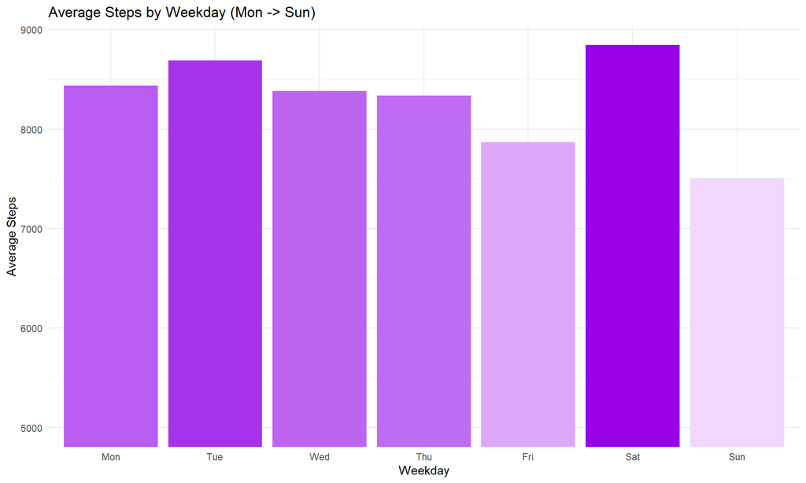

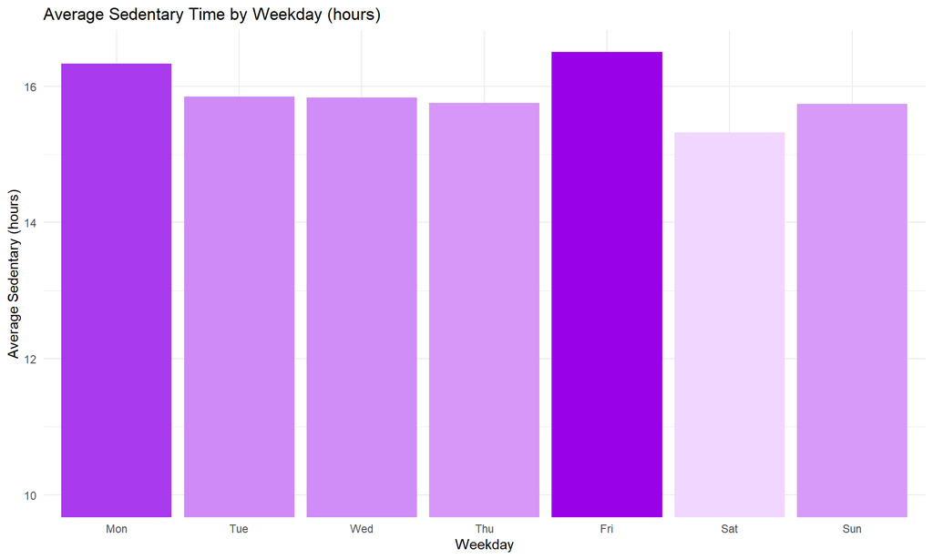

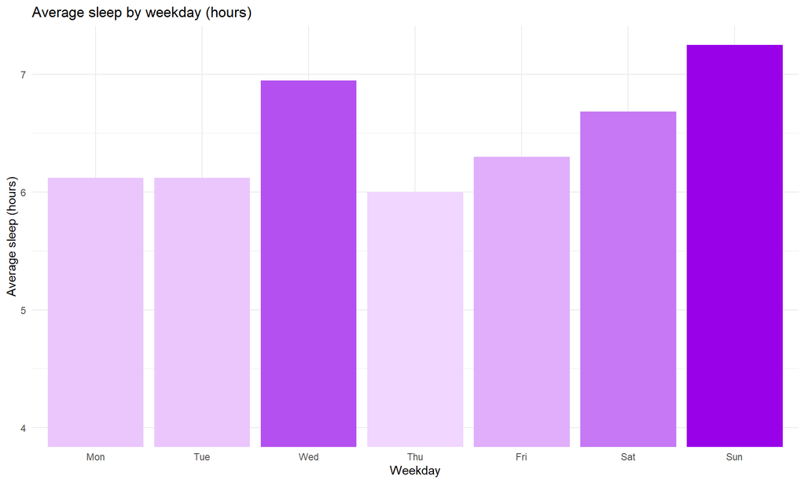

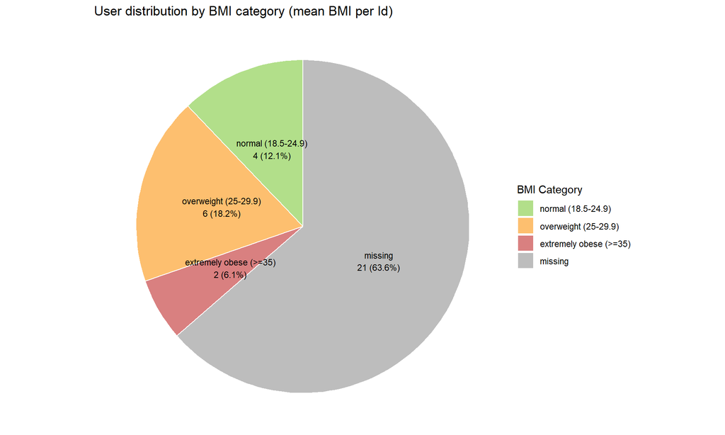

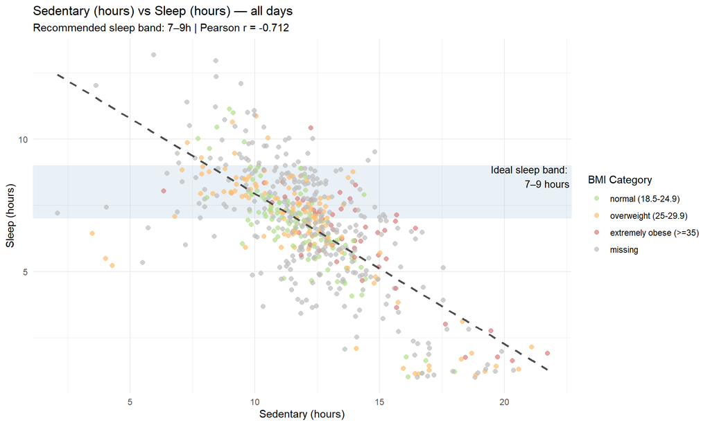

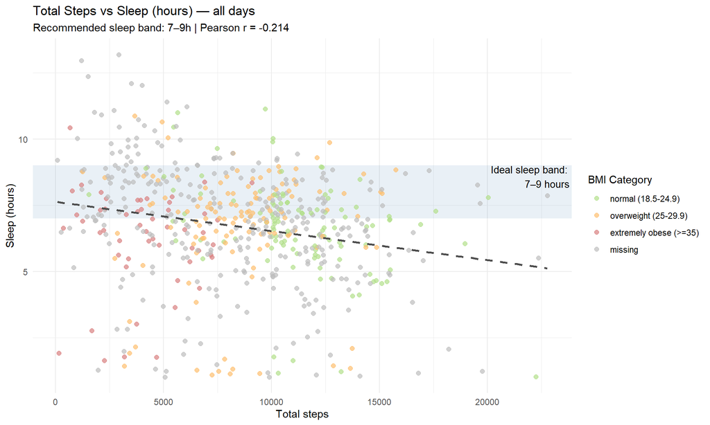

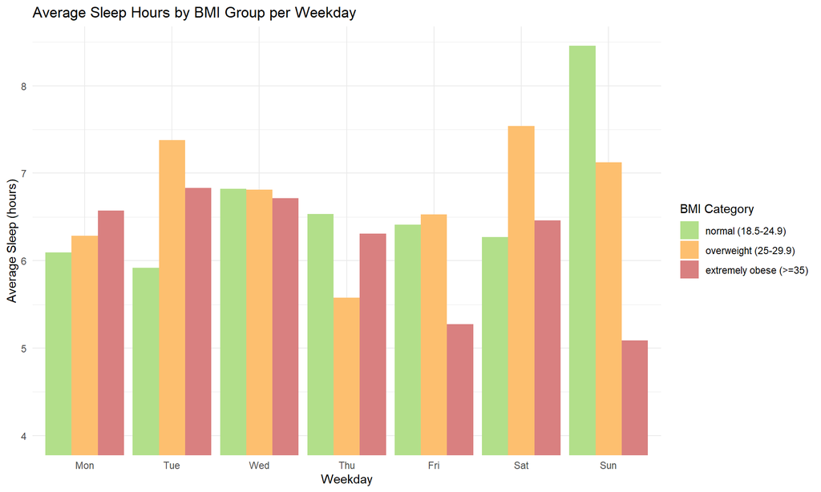

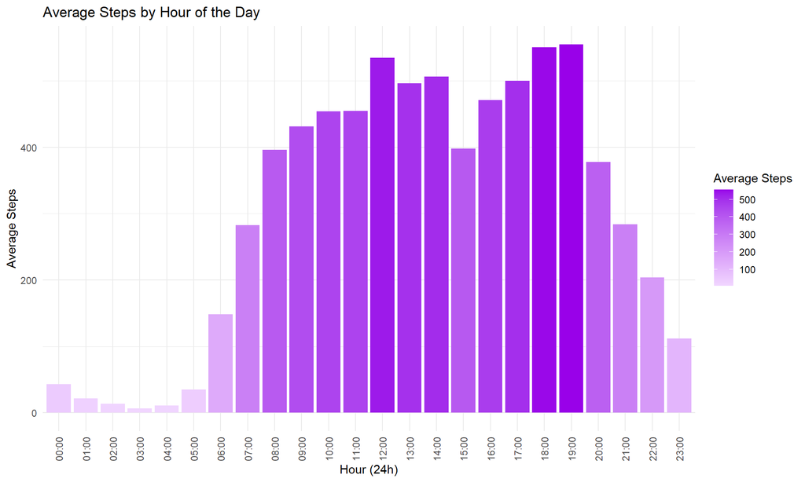

### 4.2. Summary of Findings

#### Trends in Smart Device Usage

#### Activity Patterns

- The average steps per day show that **Saturday** and **Tuesday** are the most active days, while **Sunday** and **Friday** have the lowest activity.
- Peak activity hours during the day occur at **12 PM** and in the late afternoon (**6–7 PM**).

#### Sleep Patterns

- **Sunday** shows the highest average sleep, followed by **Wednesday**; **Saturday** also has a good average sleep duration.
- **Thursday**, followed by **Monday** and **Tuesday**, shows the lowest sleep averages, indicating lower sleep quality after less active days.

#### BMI and User Segmentation

- Most users did not record their weight (**63.6% Missing**).
- **12.1%** fall within the normal BMI range (18.5–24.9), **18.2%** are overweight, and **6.1%** are extremely obese (BMI ≥35).

#### Correlations

- **Sedentary behavior vs. sleep:** Pearson correlation **r = -0.712**, indicating that more sedentary time is associated with poorer sleep.
- **Steps vs. sleep:** weak negative correlation (**r = -0.214**), suggesting that more steps do not necessarily increase sleep duration.
- **Extremely obese users** tend to have shorter sleep duration compared to other Fitbit users.

## 5. Share (Phase: Share)

### Application to Bellabeat Customers

- **Activity Incentives:** communicate ideal hours to stay active based on peak activity times (**12 PM, 6–7 PM**).
- **Sedentary Alerts:** strategic alerts could be sent on **Monday** and **Friday**, when sedentary time is highest.
- **Sleep Guidance:** recommendations can target **Thursday, Monday, and Tuesday**, when sleep duration is lowest, to improve overall sleep quality.
- **Targeted Messaging:** campaigns can segment users by BMI, highlighting that extremely obese users have distinct activity and sleep patterns.

## 6. Act (Phase: Act)

### Top 3 Recommendations for Bellabeat

Based on the insights from our analysis, we recommend the following strategic initiatives for Bellabeat’s marketing and product teams:

#### 1. Launch the “Move Well, Sleep Well” Campaign

- **Recommendation:** Create a marketing campaign centered on the strong link between lower sedentary time and better sleep. This positions Bellabeat not just as an activity tracker, but as a holistic wellness tool.
- **Actions:**
  - **Marketing:** Develop content (blog posts, social media) explaining the science behind activity and sleep. Use the tagline “Your best day starts the day before.”
  - **Product:** Implement a new “Sleep Score Contributor” feature in the app that explicitly shows users how their daily sedentary minutes impacted their sleep quality from the previous night.

#### 2. Implement Smart, Timely Notifications

- **Recommendation:** Use push notifications strategically to prompt activity when it’s most needed and most likely to occur.
- **Actions:**
  - **Sedentary Alerts:** Send gentle reminders on Mondays and Fridays around 11 a.m. and 3 p.m. to encourage short breaks.
  - **Activity Prompts:** Send notifications for “Lunchtime Walks” (12-1 PM) and “Evening Wind-down Strolls” (6-7 PM) to capitalize on peak activity windows.
  - **Sleep Prep:** On Thursdays, when sleep is poorest, send a notification in the evening suggesting a relaxing activity to prepare for a better night’s rest.

#### 3. Develop Personalized, Data-Driven Content

- **Recommendation:** Enhance user engagement by showing them their own data in comparison to community trends.
- **Actions:**
  - **In-App Reports:** Create weekly summary reports in the app showing a user’s activity and sleep patterns versus the (anonymized) average for users in their BMI category.
  - **Challenges:** Introduce targeted challenges, like a “Weekend Warrior” badge for hitting step goals on Saturday and Sunday, or a “Weekday Wellness” streak for reducing sedentary time Monday-Friday.

### Next Steps

- **Further Analysis:** Collect more recent and demographically relevant data to validate these findings. Specifically, data on Bellabeat’s actual user base would be invaluable.
- **A/B Testing:** Implement the suggested notification schedule for a small user segment to measure its impact on engagement metrics before a full rollout.

### Notes and Caveats

- Sample size (~35) and data age (2016) limit external validity.